# Linear Regression with R

Manav Jain

## Simple Linear Regression

In this regression task we will predict the percentage of marks that a student is expected to score based upon the number of hours they studied. This is a simple linear regression task as it involves just two variables.

## R Markdown

### Reading data from remote link

```r
url <- "http://bit.ly/w-data"
data<-read.csv(url)
print("Data imported successfully")
```

```
## [1] "Data imported successfully"
```

```r
head(data)
```

```
##   Hours Scores
## 1   2.5     21
## 2   5.1     47
## 3   3.2     27
## 4   8.5     75
## 5   3.5     30
## 6   1.5     20
```

Let’s plot our data points on 2-D graph to eyeball our dataset and see if we can manually find any relationship between the data. We can create the plot with the following script:

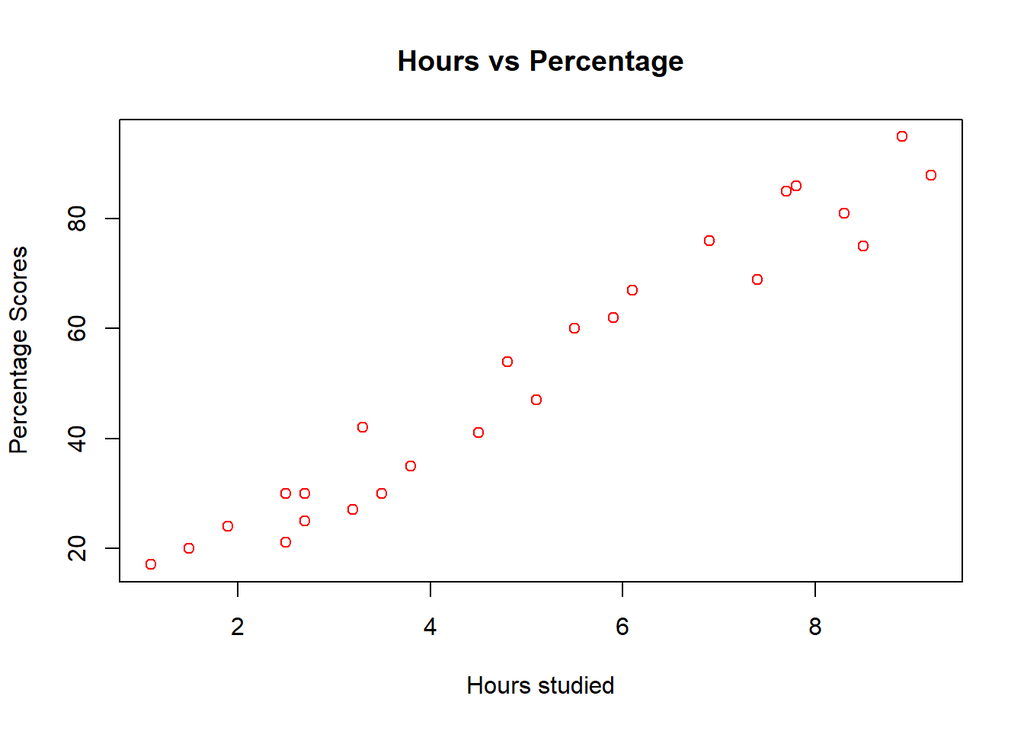

```r
plot(data$Hours,data$Scores,col="red",main="Hours vs Percentage",xlab="Hours studied",ylab="Percentage Scores")
```

From the graph above, we can clearly see that there is a positive linear relation between the number of hours studied and percentage of score.

## Preparing the data

Now that we have our attributes and labels, the next step is to split this data into training and test sets. We’ll do this by using caret library and under that createDataPartition.

```r
library(caret)
intrain<-createDataPartition(y=data$Hours,p=0.8,list=FALSE)
train<-data[intrain,]
test<-data[-intrain,]
head(train)
```

```
##   Hours Scores
## 1   2.5     21
## 2   5.1     47
## 3   3.2     27
## 4   8.5     75
## 5   3.5     30
## 6   1.5     20
```

## Training the Algorithm and Fit a Linear Model

We have split our data into training and testing sets, and now is finally the time to train our algorithm.

```r
lm1<-lm(Scores~Hours,data=train)
print("Training complete.")
```

```
## [1] "Training complete."
```

```r
summary(lm1)
```

```
##
## Call:
## lm(formula = Scores ~ Hours, data = train)
##
## Residuals:
##     Min      1Q  Median      3Q     Max
## -11.138  -4.872   2.035   5.021   6.915
##
## Coefficients:
##             Estimate Std. Error t value Pr(>|t|)
## (Intercept)   0.5728     2.8091   0.204    0.841
## Hours        10.0665     0.5053  19.922 3.42e-14 ***
## ---
## Signif. codes:  0 '***' 0.001 '**' 0.01 '*' 0.05 '.' 0.1 ' ' 1
##
## Residual standard error: 5.672 on 19 degrees of freedom
## Multiple R-squared:  0.9543, Adjusted R-squared:  0.9519
## F-statistic: 396.9 on 1 and 19 DF,  p-value: 3.42e-14
```

## Plotting the regression line

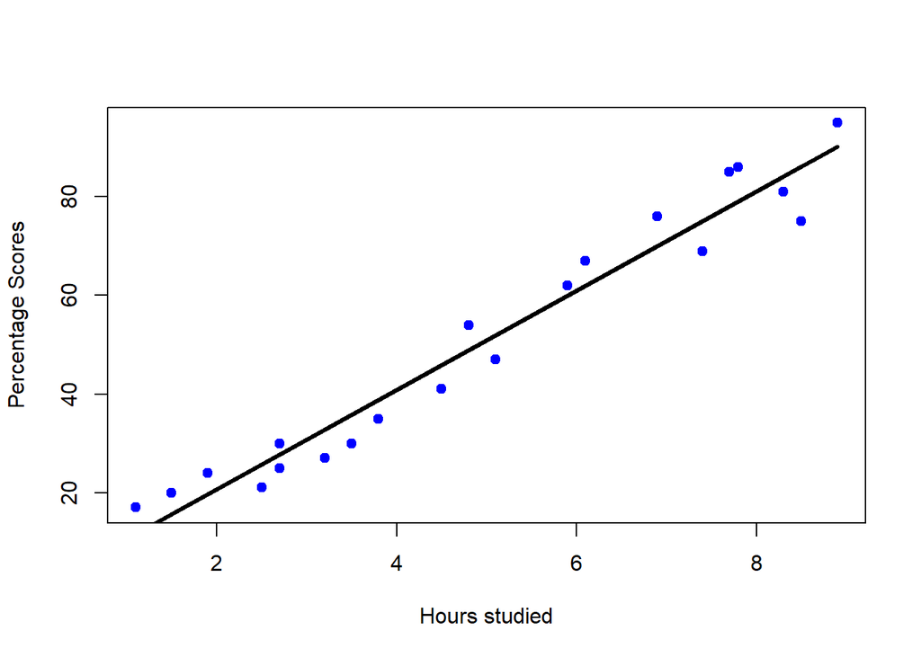

```r
plot(train$Hours,train$Scores,pch=19,col="blue",xlab="Hours studied",ylab="Percentage Scores")
lines(train$Hours,lm1$fitted,lwd=3)
```

## Making Predictions

Now that we have trained our algorithm, it’s time to make some predictions.

```r
#This our the values for testing data
neww<-data.frame(Hours=test$Hours)#testing data
predict(lm1,neww)
```

```
##        1        2        3        4
## 93.18476 55.93865 33.79232 25.73910
```

```r
#When hours = 9.25
new<-data.frame(Hours=9.25)
predict(lm1,new)
```

```
##        1
## 93.68809
```

## Evaluating the model

```r
#Calculate RMSE on training
sqrt(sum((lm1$fitted-train$Scores)^2))
```

```
## [1] 24.72351
```

```r
#Calculate RMSE on testing
sqrt(sum((predict(lm1,newdata = test)-test$Scores)^2))
```

```
## [1] 11.35331
```